# **Lecture05 - Introducción a las redes neuronales recurrentes**

- Diferentes formas de modelar texto (secuencias)
- Modelando secuencias con RNNs
- Diferentes tipos de tareas de modelado de secuencias
- Retropropagación a través del tiempo
- Memoria a corto/largo plazo (LSTM)
- Many to one RNNs
- Clasificadores con RNNs en PyTorch

# **Hay más de una forma de hornear un pastel.**

- **Diferentes formas de modelar texto (secuencias)**
- Modelando secuencias con RNNs
- Diferentes tipos de tareas de modelado de secuencias
- Retropropagación a través del tiempo
- Memoria a corto/largo plazo (LSTM)
- Many to one RNNs
- Clasificadores con RNNs en PyTorch

# **Un enfoque clásico para la clasificación de textos: modelo de bolsa de palabras**

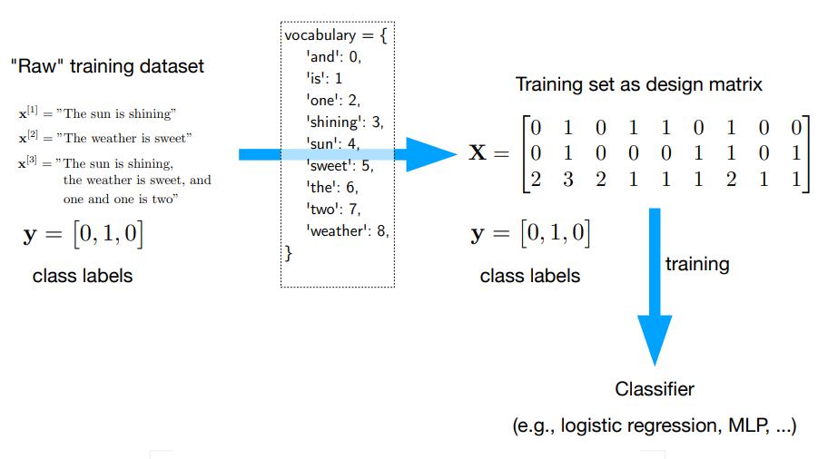

Raschka & Mirjalili. Python Machine Learning 3rd Ed. https://github.com/rasbt/python-machine-learning-book-3rd-edition/blob/master/ch08/ch08.ipynb

# **CNN 1D para texto (y otros datos de secuencia)**

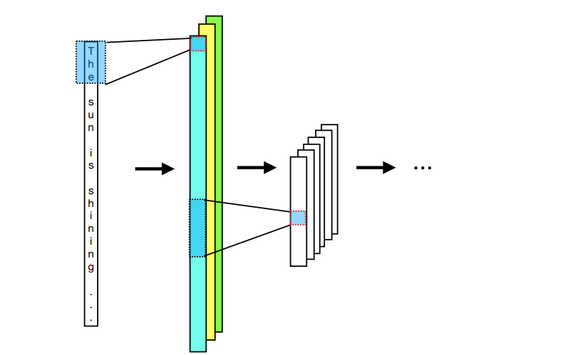

# **Embeddings y aprendizaje autónomo supervisado**

**Sentencia de entrada:** A quick brown $\color{orange}{fox}$ jumps over the lazy dog

**15% enmascarado al azar:** A quick brown $\color{orange}{[MASK]}$ jumps over the lazy dog

[figure not shown]

# **¿Cómo se puede modificar MLPs para capturar información de secuencia?**

- Diferentes formas de modelar texto (secuencias)
- **Modelando secuencias con RNNs**
- Diferentes tipos de tareas de modelado de secuencias
- Retropropagación a través del tiempo
- Memoria a corto/largo plazo (LSTM)
- Many to one RNNs
- Clasificadores con RNNs en PyTorch

# **Datos de secuencia: el orden importa**

La película que mi amigo **no** ha visto es buena

La película que mi amigo ha visto **no** es buena

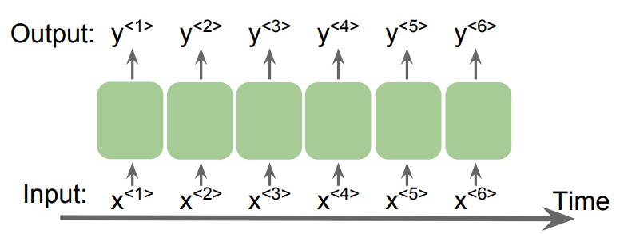

Fuente de la imange: Sebastian Raschka, Vahid Mirjalili. Python Machine Learning. 3rd Edition. Packt, 2019

# **Aplicaciones: Trabajar con datos secuenciales**

- Clasificación de texto
- Reconocimiento de voz (modelado acústico)
- Traducción de idiomas
- Modelado de secuencias de ADN o (aminoácidos / proteínas)
- ...

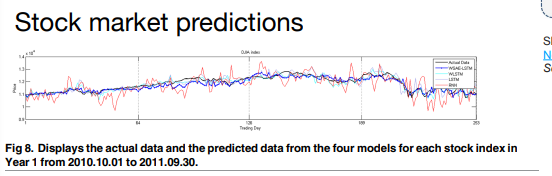

https://doi.org/10.1371/journal.pone.0180944.g008

Bao, Wei, Jun Yue, and Yulei Rao. "A deep learning framework for financial time series using stacked autoencoders and long-short term memory." PloS one 12, no. 7 (2017): e0180944

https://journals.plos.org/plosone/article?id=10.1371/journal.pone.0180944

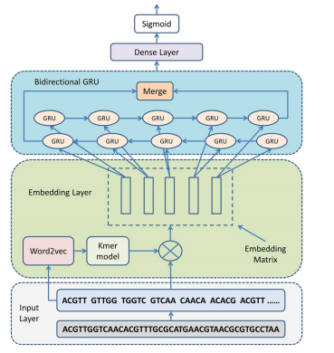

Shen, Zhen, Wenzheng Bao, and De-Shuang. "Recurrent Neural Network for Predicting Transcription Factor Binding Sites." Scientific reports 8, no. 1 (2018): 15270.

https://www.nature.com/articles/s41598-018-33321-1

# **Visión general**

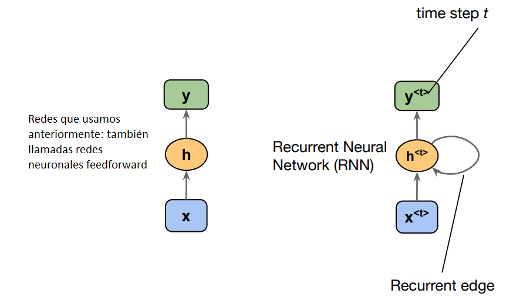

Image source: Sebastian Raschka, Vahid Mirjalili. Python Machine Learning. 3rd Edition. Packt, 2019

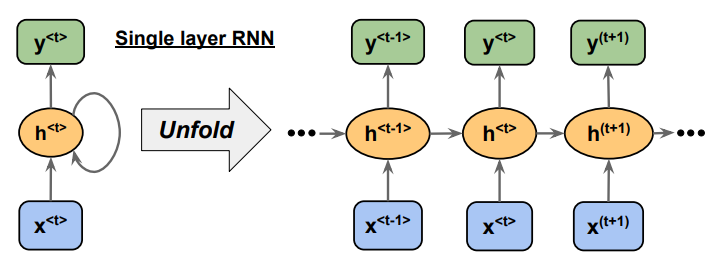

# **Visión general**

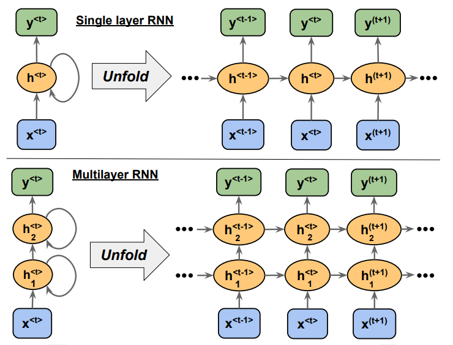

Image source: Sebastian Raschka, Vahid Mirjalili. Python Machine Learning. 3rd Edition. Packt, 2019

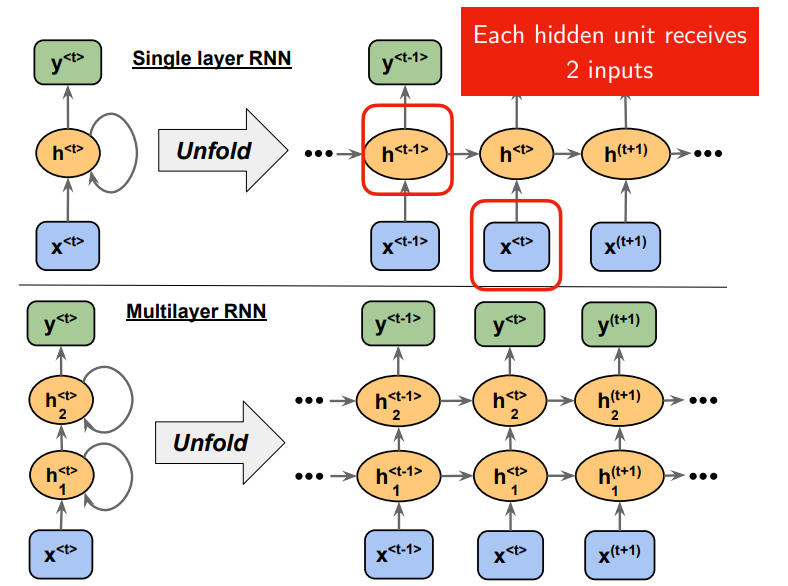

Image source: Sebastian Raschka, Vahid Mirjalili. Python Machine Learning. 3rd Edition. Packt, 2019

# **Las cosas simples nunca son simples, ¿verdad?**

- Diferentes formas de modelar texto (secuencias)
- Modelando secuencias con RNNs
- **Diferentes tipos de tareas de modelado de secuencias**
- Retropropagación a través del tiempo
- Memoria a corto/largo plazo (LSTM)
- Many to one RNNs
- Clasificadores con RNNs en PyTorch

# **Diferentes tipos de tareas de modelado de secuencias**

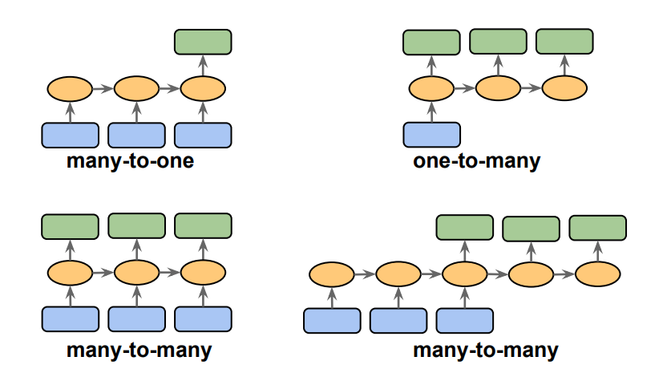

Image source: Sebastian Raschka, Vahid Mirjalili. Python Machine Learning. 3rd Edition. Packt, 2019

Figura basada en: The Unreasonable Effectiveness of Recurrent Neural Networks by Andrej Karpathy (http://karpathy.github.io/2015/05/21/rnn-effectiveness/)

# **Diferentes tipos de tareas de modelado de secuencias**

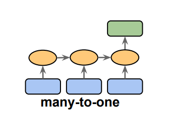

**Many to one:** Los datos de entrada son una secuencia, pero la salida es un vector de tamaño fijo, no una secuencia.

Ejemplo: Análisis de sentimiento, la entrada es un texto y la salida es una etiqueta de clase.

# **Diferentes tipos de tareas de modelado de secuencias**

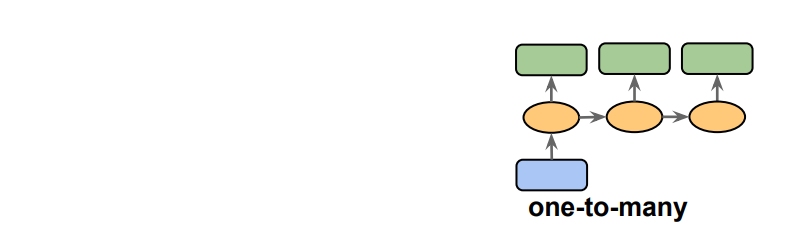

**One to many:** Los datos de entrada están en un formato estándar (no una secuencia), la salida es una secuencia.

Ejemplo: Subtítulos de imágenes, donde la entrada es una imagen, la salida es una descripción de texto de esa imagen

# **Diferentes tipos de tareas de modelado de secuencias**

**Many to many:** Tanto las entradas como las salidas son secuencias. Puede ser directo o retrasado.

Ejemplo: Subtítulos de video, es decir, describir una secuencia de imágenes a través de texto (directo).

Traducir un idioma a otro (retrasado)

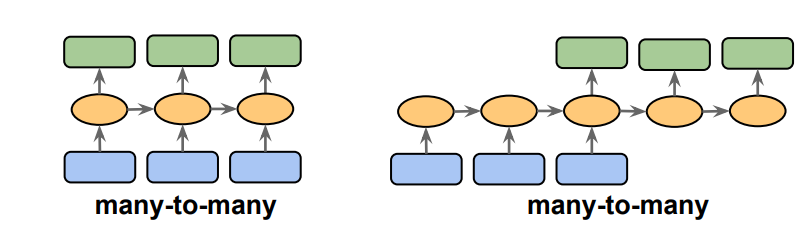

# **Cómo se ven las RNN bajo el capó**

- Diferentes formas de modelar texto (secuencias)
- Modelando secuencias con RNNs
- Diferentes tipos de tareas de modelado de secuencias
- **Retropropagación a través del tiempo**
- Memoria a corto/largo plazo (LSTM)
- Many to one RNNs
- Clasificadores con RNNs en PyTorch

# **Matrices de peso en una sola capa oculta RNN**

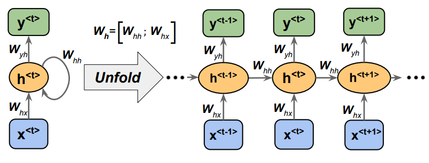

Image source: Sebastian Raschka, Vahid Mirjalili. Python Machine Learning. 3rd Edition. Packt, 2019

# **Matrices de peso en una sola capa oculta RNN**

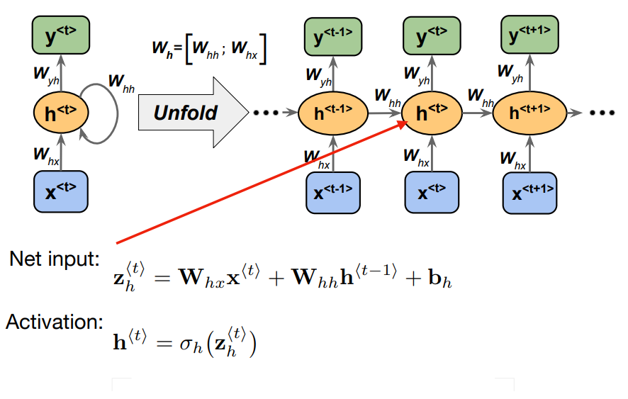

Image source: Sebastian Raschka, Vahid Mirjalili. Python Machine Learning. 3rd Edition. Packt, 2019

# **Matrices de peso en una sola capa oculta RNN**

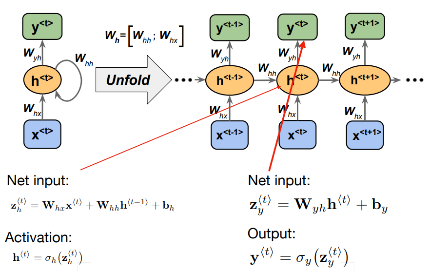

Image source: Sebastian Raschka, Vahid Mirjalili. Python Machine Learning. 3rd Edition. Packt, 2019

# **Retropropagación a través del tiempo**

La pérdida total se puede calcular como la suma de todos los pasos de tiempo.

Werbos, Paul J. "Backpropagation through time: what it does and how to do it." Proceedings of the IEEE 78, no. 10 (1990): 1550-1560.

http://axon.cs.byu.edu/Dan/678/papers/Recurrent/Werbos.pdf

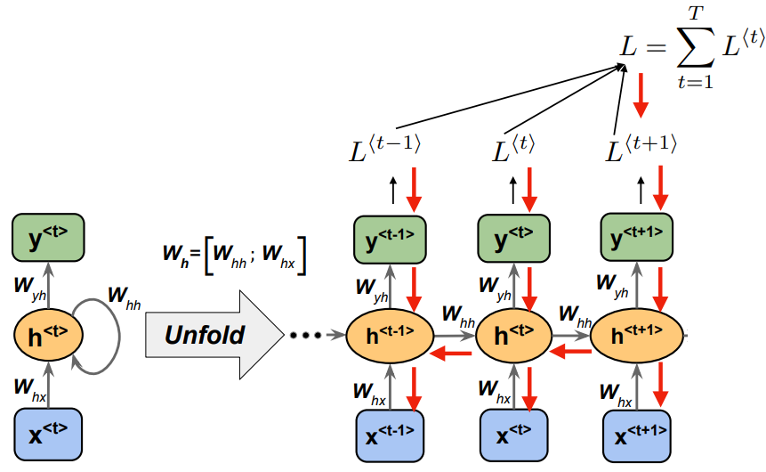

Image source: Sebastian Raschka, Vahid Mirjalili. Python Machine Learning. 3rd Edition. Packt, 2019

# **Retropropagación a través del tiempo**

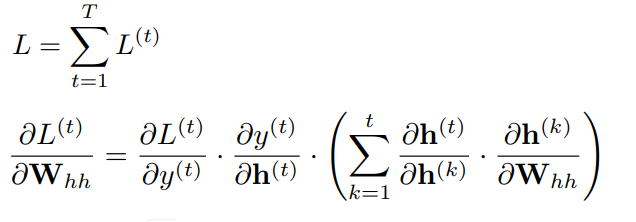

Werbos, Paul J. "Backpropagation through time: what it does and how to do it." Proceedings of the IEEE 78, no. 10 (1990): 1550-1560.

http://axon.cs.byu.edu/Dan/678/papers/Recurrent/Werbos.pdf

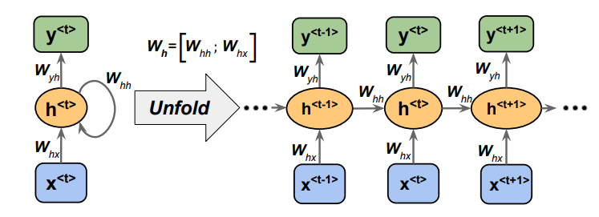

# **Retropropagación a través del tiempo**

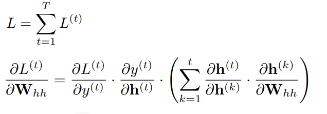

Werbos, Paul J. "Backpropagation through time: what it does and how to do it." Proceedings of the IEEE 78, no. 10 (1990): 1550-1560.

http://axon.cs.byu.edu/Dan/678/papers/Recurrent/Werbos.pdf

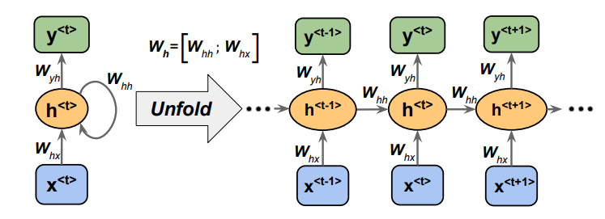

# **Retropropagación a través del tiempo**

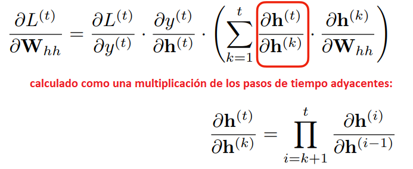

Werbos, Paul J. "Backpropagation through time: what it does and how to do it." Proceedings of the IEEE 78, no. 10 (1990): 1550-1560.

http://axon.cs.byu.edu/Dan/678/papers/Recurrent/Werbos.pdf

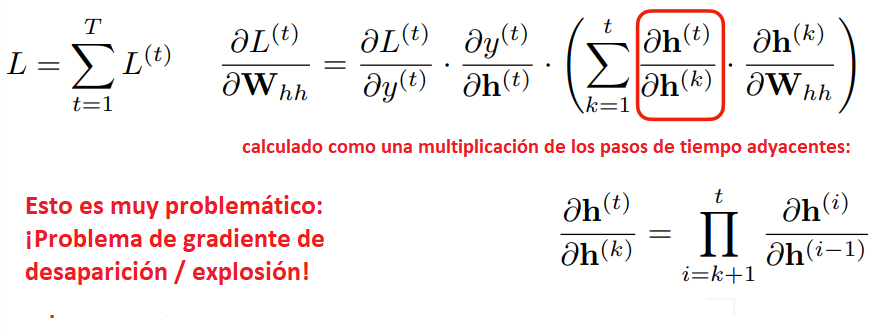

# **Modelando dependencias de largo alcance**

- Diferentes formas de modelar texto (secuencias)
- Modelando secuencias con RNNs
- Diferentes tipos de tareas de modelado de secuencias
- Retropropagación a través del tiempo
- **Memoria a corto/largo plazo (LSTM)**
- Many to one RNNs
- Clasificadores con RNNs en PyTorch

# **Soluciones a los problemas de gradiente de desaparición/explosión**

- Gadient clipping: Establecer un valor máximo para los gradientes si crecen demasiado (solo resuelve el problema del gradiente explosivo)
- Propagación hacia atrás truncada a través del tiempo (TBPTT): Simplemente limita el número de pasos de tiempo que la señal puede propagarse hacia atrás después de cada pasada hacia adelante. Por ejemplo, incluso si la secuencia tiene 100 elementos/pasos, solo podemos propagar hacia atrás hasta 20 más o menos
- Memoria a largo/corto plazo (LSTM): Utiliza una celda de memoria para modelar dependencias de largo alcance y evitar problemas de gradiente que desaparecen.

Hochreiter, Sepp, and Jürgen Schmidhuber. "Long short-term memory." Neural computation 9, no. 8 (1997): 1735-1780.

https://www.mitpressjournals.org/doi/abs/10.1162/neco.1997.9.8.1735?casa_token=vRk-8IGcavsAAAAA:x4-lr64opq32GD_gVNgtGQtRD58x5ipJafRbotD35B2wm9l4xmzAdg8c0nP7H-SdL1dqHYuVnw

# **Memoria a corto/largo plazo (LSTM)**

## Long-Short Term Memory

Celda LSTM:

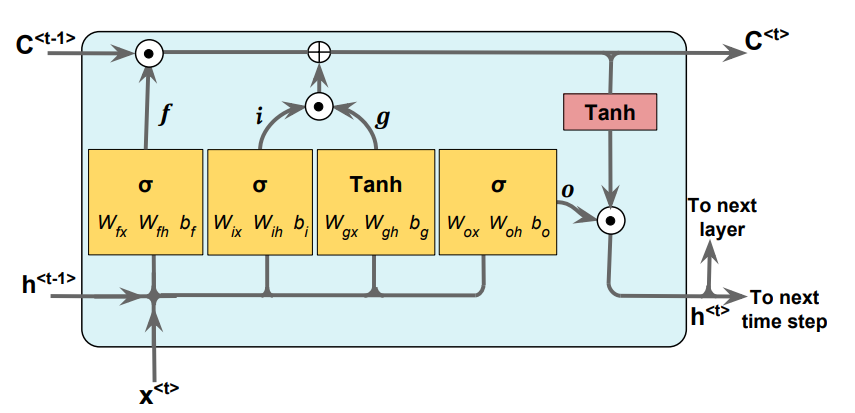

Figure: Sebastian Raschka, Vahid Mirjalili. Python Machine Learning. 3rd Edition. Birmingham, UK: Packt Publishing, 2019

[figure not shown]

# **Memoria a corto/largo plazo (LSTM)**

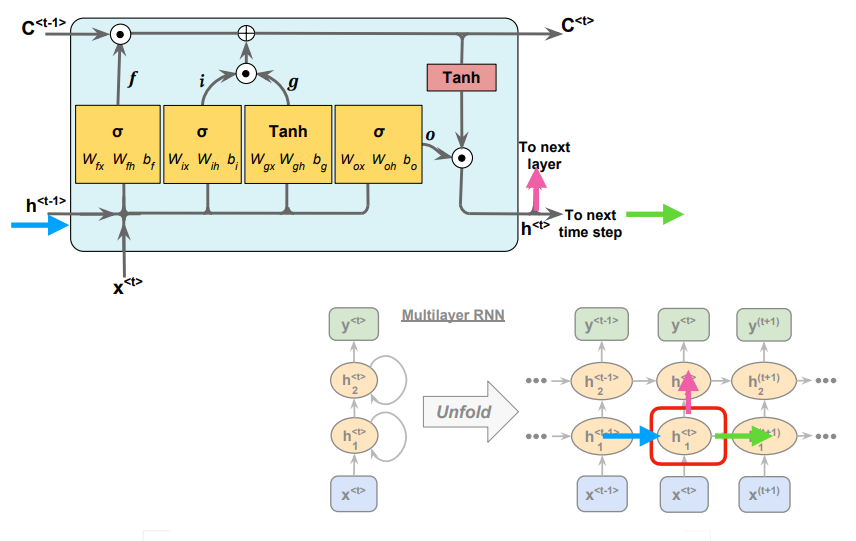

# **Memoria a corto/largo plazo (LSTM)**

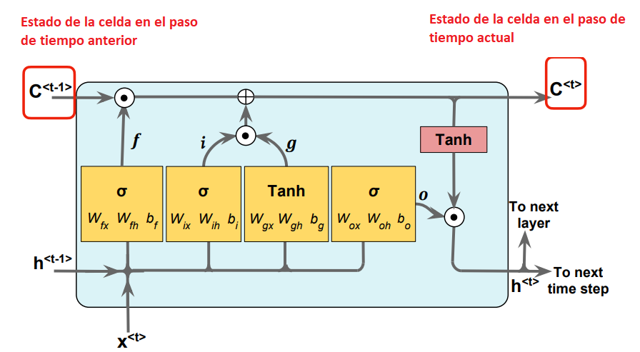

# **Memoria a corto/largo plazo (LSTM)**

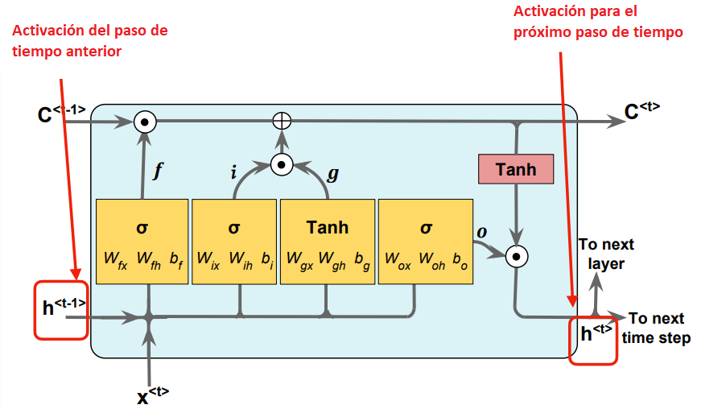

# **Memoria a corto/largo plazo (LSTM)**

Gers, Felix A., Jürgen Schmidhuber, and Fred Cummins. "Learning to forget: Continual prediction with LSTM." (1999): 850-855.

https://digital-library.theiet.org/content/conferences/10.1049/cp_19991218

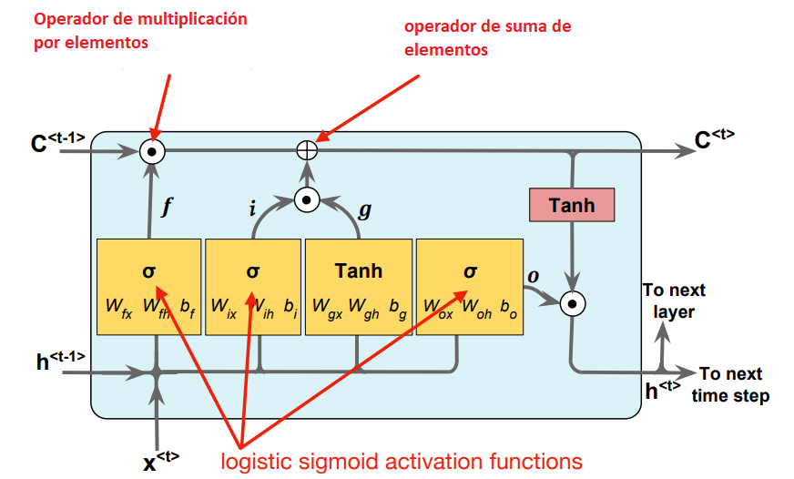

# **Memoria a corto/largo plazo (LSTM)**

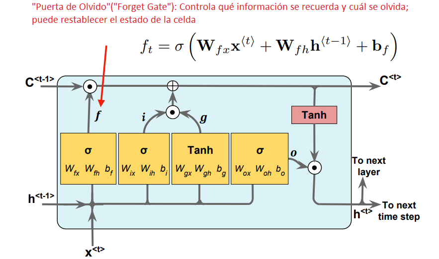